# Practice Activity Week 4

```r
library(tidyverse)
library(ggalluvial)
```

# Roundabouts

This week, our activity will explore how roundabouts are used around the world! You might not be as big of a fan of roundabouts as Dr. T, but these data allow us to investigate a fun and unique visualization technique—[a Sankey diagram](https://en.wikipedia.org/wiki/Sankey_diagram).

A Sankey diagram visualizes data **flows**. Specifically, the visual models the movement from one state to another. We are going to use a Sankey plot to visualize how traffic intersections are transformed into various types of roundabouts.

## The `roundabouts` Package

The [`roundabouts` R package](https://github.com/EmilHvitfeldt/roundabouts) provides a simple way to interact with the [Roundabouts Database](https://roundabouts.kittelson.com/). You likely do not have the package installed on your computer, so the first step is to install the package:

```r
pak::pak("emilhvitfeldt/roundabouts")
# remotes::install_github("emilhvitfeldt/roundabouts")  # alternative if pak isn't working
```

The `roundabouts` dataframe that is included in the package has an `address` variable which is a bit untidy. Below is some data cleaning code that will clean the `address` variable, and create three new variables: `town_city`, `county_area`, and `state_region`.

```r
library(roundabouts)

roundabouts_clean <- roundabouts |>
  mutate(
    # Step 1: Remove strange <![CDATA[ tags from the beginning of the address field
    address = stringr::str_remove(address, stringr::fixed("<![CDATA[")),
    # Step 2: Remove strang ]]> tags from the end of the address field
    address = stringr::str_remove(address, stringr::fixed("]]>")),
    # Step 3: Isolate the country at the end of the string between the ( ) symbols
    country = stringr::str_extract(address, "\\([^)]+\\)$"),
    # Step 4: Remove the brackets surrounding the country name
    country = stringr::str_remove_all(country, "[\\(\\)]"),
    # Step 5: Remove the country from the address field
    address2 = stringr::str_remove(address, "\\s*\\([^)]+\\)$")) |>
  # Step 6: Separate address into town, county, state by comma
  separate(address2,
                  into = c("town_city", "county_area", "state_region"),
                  sep = ",") |>
  # Step 7: Fix one instance of California instead of CA
  mutate(state_region = str_trim(state_region, side = "both"),
         state_region = fct_recode(state_region,
                                   "CA" = "California")
         ) |>
  # Step 8: Remove companies from states
  filter(! str_detect(state_region, pattern = "Co.")) |>
  # Step 9: Grab columns we will be using
  select(town_city, county_area, state_region, country,
         year_completed, type, previous_control_type, control_type)
```

## Creating a Region Variable

Alright, we now have the `country` of each roundabout, but that seems to fine grain for our analysis. If we’re interested in how roundabouts are used around the world, it seems like a `region` variable might be a better fit.

1. Create a new `continent` column in the dataset, which classifies each `country` into one of the five major continents—Americas, Europe, Asia, Oceania, Africa.

The `countrycode()` function from the `countrycode` package will be helpful here! Here is an example of how you can use this function to obtain the continent of a given country:

```r
countrycode::countrycode("Brazil",
            origin = "country.name",
            destination = "continent")
```

```r
roundabouts_clean<-roundabouts_clean|>
  mutate(
    continent = countrycode::countrycode(country,
                                         origin = "country.name",
                                         destination = "continent"))
```

## Exploring Roundabouts

Let’s explore the data a bit before we jump into visualizing these data.

2. What countries have the most roundabouts (of any type) in these data? The fewest roundabouts?

```r
roundabouts_clean|>
  count(country)|>
  arrange(-n)
```

```
# A tibble: 75 × 2
   country            n
   <chr>          <int>
 1 United States  12907
 2 Australia       3369
 3 United Kingdom  1777
 4 Canada          1245
 5 New Zealand      860
 6 Netherlands      759
 7 Russia           472
 8 Norway           467
 9 France           362
10 Spain            281
# ℹ 65 more rows
```

United States has the most roundabounts

3. In these data, what types of roundabouts are most common?

```r
roundabouts_clean|>
  count(type)|>
  arrange(-n)
```

```
# A tibble: 6 × 2
  type                             n
  <chr>                        <int>
1 Roundabout                   20271
2 Other                         2825
3 Traffic Calming Circle         798
4 Unknown                        334
5 Rotary                         289
6 Signalized Roundabout/Circle   252
```

The most common types of roundabouts are regular roundabounts, other, and traffic calming circles.

4. How does the distribution of types differ by continent? *Hint: Proportions are the easiest way to address this question!*

```r
roundabouts_clean|>
  count(type,continent)|>
  group_by(continent)|>
  mutate(
    total = sum(n),
    percent = n/total
  )
```

```
# A tibble: 27 × 5
# Groups:   continent [5]
   type   continent     n total percent
   <chr>  <chr>     <int> <int>   <dbl>
 1 Other  Africa        1   100 0.01
 2 Other  Americas   2447 14364 0.170
 3 Other  Asia         42   187 0.225
 4 Other  Europe      330  5882 0.0561
 5 Other  Oceania       5  4236 0.00118
 6 Rotary Africa        1   100 0.01
 7 Rotary Americas    189 14364 0.0132
 8 Rotary Asia         25   187 0.134
 9 Rotary Europe       56  5882 0.00952
10 Rotary Oceania      18  4236 0.00425
# ℹ 17 more rows
```

5. We’ve seen a lot of traffic calming circles showing up around SLO. What states in the US have the largest proportion of traffic calming circles?

```r
roundabouts_clean|>
  filter(country=="United States")|>
  count(state_region,type)|>
  group_by(state_region)|>
  mutate(
    total = sum(n),
    percent = n/total
  )|>
  filter(type=="Traffic Calming Circle")|>
  arrange(-percent)
```

```
# A tibble: 37 × 5
# Groups:   state_region [37]
   state_region type                       n total percent
   <fct>        <chr>                  <int> <int>   <dbl>
 1 OR           Traffic Calming Circle    76   254  0.299
 2 WA           Traffic Calming Circle   129   658  0.196
 3 DC           Traffic Calming Circle     3    17  0.176
 4 CA           Traffic Calming Circle   124   815  0.152
 5 MA           Traffic Calming Circle    23   199  0.116
 6 AZ           Traffic Calming Circle    22   198  0.111
 7 AL           Traffic Calming Circle    10    96  0.104
 8 HI           Traffic Calming Circle     4    39  0.103
 9 FL           Traffic Calming Circle   140  1455  0.0962
10 AK           Traffic Calming Circle     5    54  0.0926
# ℹ 27 more rows
```

# The `ggalluvial` Package

Now that we have the data ready, let’s explore making Sankey plots with the [`ggalluvial` R package](https://corybrunson.github.io/ggalluvial/).

We are interested in visualizing how roundabouts are incorporated into traffic intersections. To do this, we will visualize the *flow* from the previous intersection type to the type of roundabout that was added, to the final intersection (control) type.

Let’s start by creating the data `gglluvial` requires for plotting.

6. Create a table of frequencies of previous intersection types, current intersection types, and roundabouts. Let’s focus on intersections (both old and new) where the type was known (not labeled as `"Unknown"`).

```r
round_summ<-roundabouts_clean |>
  filter(previous_control_type!="Unknown",
         control_type!="Unknown",
         type!="Unknown")|>
  count(type, previous_control_type, control_type)
```

## Customizing Labels – Required for 541, Optional for 431

7. Now create the Sankey plot using the data you made above! Your axes should be previous control type and the current control type, and the colors should be associated with the type of roundabout. *Hint: You might find the [ggalluvial reference page helpful](https://corybrunson.github.io/ggalluvial/)!*

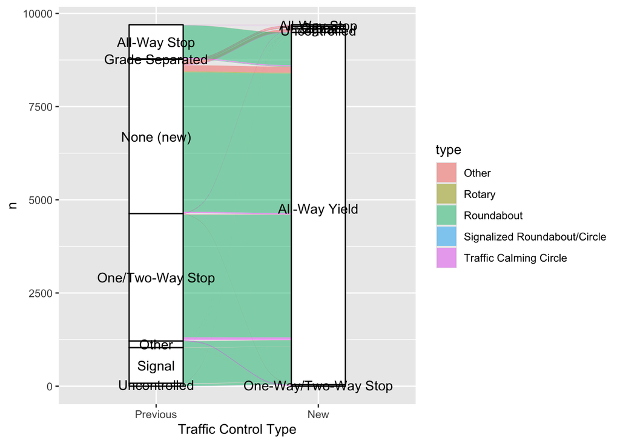

```r
library(ggalluvial)
ggplot(data = round_summ,
       aes(axis1=previous_control_type,axis2=control_type,y=n))+
  geom_alluvium(aes(fill=type))+
  geom_stratum()+
  geom_text(stat = "stratum",aes(label = after_stat(stratum)))+
  scale_x_discrete(limits=c("Previous","New"))+
  xlab("Traffic Control Type")
```

8. Now that you have a working solution, let’s make the strata labels easy to read. Look over this [reference article](https://corybrunson.github.io/ggalluvial/articles/labels.html) on different ways to label the strata for each axis. Implement your favorite method!

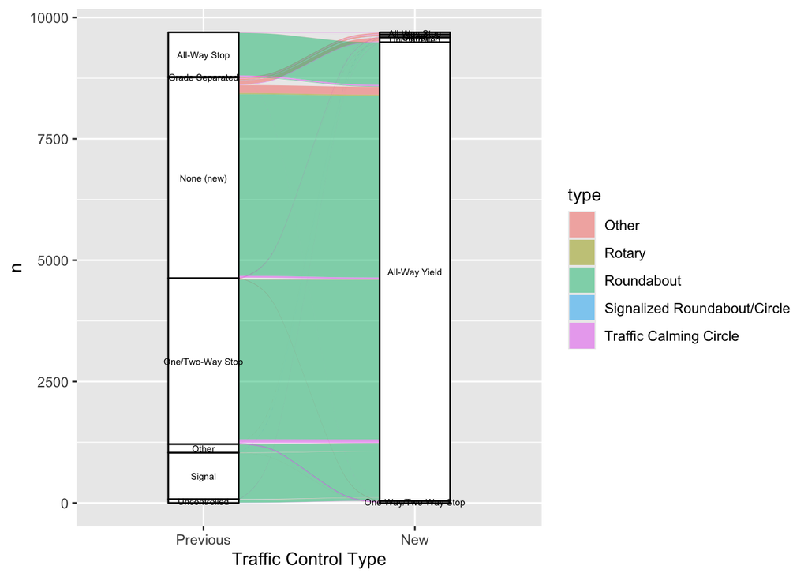

```r
ggplot(data = round_summ,
       aes(axis1=previous_control_type,axis2=control_type,y=n))+
  geom_alluvium(aes(fill=type))+
  geom_stratum()+
  geom_text(stat = "stratum",
            aes(label = after_stat(stratum)),
            size=2)+
  scale_x_discrete(limits=c("Previous","New"))+
  xlab("Traffic Control Type")
```

## Customizing Colors – Required for Both 541 and 431

9. Final touches! Let’s add some custom colors and an informative plot title! *Each of the axes in your plot should have a title as well!*

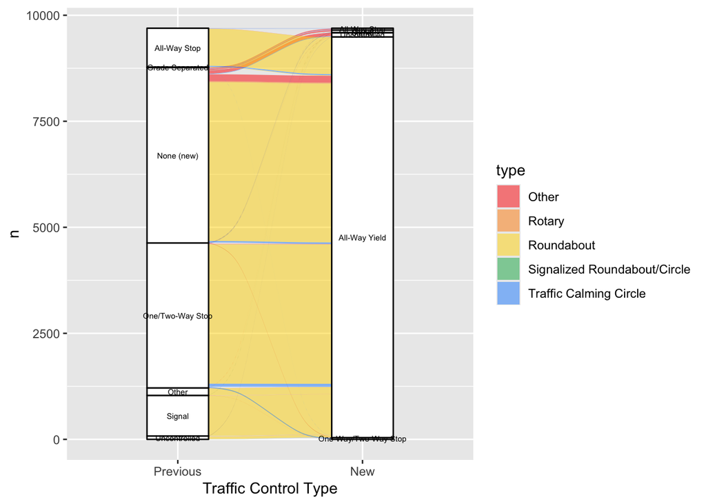

```r
ggplot(data = round_summ,
       aes(axis1=previous_control_type,axis2=control_type,y=n))+
  geom_alluvium(aes(fill=type))+
  geom_stratum()+
  geom_text(stat = "stratum",
            aes(label = after_stat(stratum)),
            size=2)+
  scale_x_discrete(limits=c("Previous","New"))+
  xlab("Traffic Control Type")+
  scale_fill_manual(
  values = c(
    "Other"                          = "#FF0000",
    "Rotary"                         = "#FF8C00",
    "Roundabout"                     = "#FFD700",
    "Signalized Roundabout/Circle"   = "#00B050",
    "Traffic Calming Circle"         = "#1E90FF"
  )
)
```